(tp:sd)=

# Types composés

**Connaissances abordées :** types composés de python

- les types non mutables de python : `tuple` et `str`
- les types mutables de python : `list`, `set` et `dict`

Et aussi :

- `pyplot` de `matplotlib`

On va commencer par diverses créations de listes `list` et dictionnaires `dict`

**Remarque préalable**

Terminer chaque question en affichant le résultat du traitement demandé.

## Listes en compréhension

Ce mécanisme est très utile. L'appliquer pour obtenir les listes correspondant aux traitements suivants.

1. ajouter 5 à chaque élément de la liste des entiers compris entre 0 et 10.
2. ajouter 5 à chaque élément de la liste des entiers pairs compris entre 0 et 10.

```python
# ENTRER VOTRE CODE A LA PLACE DE CES 2 LIGNES
raise NotImplementedError()
```

## Dictionnaires en compréhension

Définir à l'aide de ce mécanisme l'ensemble des couples $(n, n^2)$ pour les entiers $n$ impairs compris entre 1 et 10.

```python
# ENTRER VOTRE CODE A LA PLACE DE CES 2 LIGNES
raise NotImplementedError()
```

## Parcourir deux listes

A partir des listes `[u,p,v,d]` et `[p,e,r,p,i]`, utiliser une liste en compréhension pour obtenir la liste :  
`['up', 'ue', 'ur', 'up', 'ui', 'pp', 'pe', 'pr', 'pp', 'pi', 'vp', 've', 'vr', 'vp', 'vi', 'dp', 'de', 'dr', 'dp', 'di'`.  
Afficher la liste résultat.

```python
# ENTRER VOTRE CODE A LA PLACE DE CES 2 LIGNES
raise NotImplementedError()
```

# Dictionnaire français-anglais

1. Ecrire une fonction `inverse()` qui échange les clés et les valeurs d'un dictionnaire donné et retourne un nouveau dictionnaire "inversé".
2. Application pour la traduction français <-> anglais :
   - définir un dictionnaire avec quelques paires de mots francais/anglais (unicité de chaque mot dans une langue donnée)
   - appliquer la fonction pour obtenir un dictionnaire anglais/français
   - Ecrire quelques tests de chaque dictionnaire

```python
# ENTRER VOTRE CODE A LA PLACE DE CES 2 LIGNES
raise NotImplementedError()
```

# Ensembles

## Définition

Définir puis afficher les deux ensembles : `A = {u,p,v,d}` et `B = {p,e,r,p,i}`.

```python
# ENTRER VOTRE CODE A LA PLACE DE CES 2 LIGNES
raise NotImplementedError()
```

## Appartenance et autres opérations ensemblistes

Vérifier l'appartenance ou non des caractères `v` et `p` :

1. à chacun des ensembles `A` puis `B`
2. à leur intersection
3. à leur union
4. aux ensembles différences `A\B` et `B\A`
5. à la différence symétrique `A ^ B`

Afficher le résultat de l'appartenance de `v` puis de `p`, et l'ensemble testé.  
La première question donne l'affichage suivant :  
`True True {'u', 'v', 'd', 'p'}`

```python
# ENTRER VOTRE CODE A LA PLACE DE CES 2 LIGNES
raise NotImplementedError()
```

(tp-sd:dictionnaire)=

# Mini base de données

Une mini base de données avec un dictionnaire.

*Remarque* : la plupart des traitements sur une base de données comporte des entrées-sorties : choix entrés au clavier, résultat des requêtes (traitements) affichés à l'écran.

## Structure de données et premiers pas

### Définition

A partir du tableau suivant, définir un dictionnaire `cops` avec les noms d'une série de copains, leur âge et leur taille.

| nom | âge en années | taille en cm |
| --- | --- | --- |
| Pierre | 21 | 178 |
| Paul | 20 | 183 |
| Pauline | 19 | 165 |
| Paola | 20 | 163 |

Le nom servira de *clé* et la *valeur* composée de l'âge et la taille est défini avec un tuple.  
L'âge est un entier et la taille sera exprimée *en mètre* avec un nombre flottant.

On appellera *élément* le triplet clé:(age, taille).

```python
# ENTRER VOTRE CODE A LA PLACE DE CES 2 LIGNES
raise NotImplementedError()
```

```python
# Ne pas écrire dans cette cellule
```

### Affichages

Effectuer sur ce dictionnaire les traitements de parcours et d'affichage suivants :

1. parcours selon les clés et affichage des clés
2. parcours selon les clés et affichage des couples (clé, valeur)
3. parcours selon les valeurs et affichage des valeurs (age, taille)
4. parcours selon les valeurs et affichage des tailles
5. parcours selon les éléments (clé:valeur) et affichage des couples (clé, valeur)
6. parcours et affichage des couples (clé, **age**)

```python
# ENTRER VOTRE CODE A LA PLACE DE CES 2 LIGNES
raise NotImplementedError()
```

### Premier ajout

Ajouter un nouvel élément et compter le nombre d'éléments du dictionnaire.

```python
# ENTRER VOTRE CODE A LA PLACE DE CES 2 LIGNES
raise NotImplementedError()
```

## Requêtes de base

Des requêtes classiques en base de données sont :

- des requêtes de consultation
- des requêtes de mise à jour.

On va écrire quelques-unes d'entre elles sous la forme de *fonctions*.  
Il est conseillé de lire toutes les requêtes demandées pour choisir un ordre de développement efficace.

**Note.** Le typage des paramètres des fonctions est :

- clé -> `str`
- valeur -> `tuple[int, float]`
- age -> `int`
- taille -> `float`
- élément -> `str:tuple[int, float]`
- dictionnaire ->`dict[tuple[int, float]]` ou plus simplement `dict` pour faciliter l'écriture du paramètre "dictionnaire".

### Les mises à jour : ajout, modification, suppression

Ecrire les fonctions qui effectuent les traitements suivants.  
Le cas échéant, signaler l'impossibilité du traitement par un affichage. Pour cela, définir une fonction `dict_error()` qui affiche un message et l'utiliser autant que de besoin.

1. `est_dans()`: vérifier si un élément de clé donnée apparaît ou non dans le dictionnaire
   - donner 2 versions différentes `est_dans()` et `est_dans2()`, la première n'utilisant pas de méthode de base
2. `ajout()`: ajouter un élément ou modifier un élément déjà existant.
3. `supp()`: suppression d'un élément à partir de sa clé.
4. `modif()`: modifier un élément à partir de sa clé.

Ecrire aussi des petits tests pour chacune des fonctions.

```python
# ENTRER VOTRE CODE A LA PLACE DE CES 2 LIGNES
raise NotImplementedError()
```

### Les consultations

Ecrire les fonctions qui effectuent les traitements suivants.  
Les cas de traitement particulier seront identifiés et traités de façon adaptée.

1. `age()`: retourne l'âge d'un élément à partir de sa clé
2. `taille()`: retourne la taille d'un élément à partir de sa clé
3. `elem()`: retourne nom, âge et taille d'un élément à partir de sa clé

```python
# ENTRER VOTRE CODE A LA PLACE DE CES 2 LIGNES
raise NotImplementedError()
```

### Les affichages

Ecrire les fonctions qui effectuent les traitements suivants.

1. `aff_age()`: afficher l'âge d'un élément à partir de sa clé
2. `aff_taille()`: afficher la taille d'un élément à partir de sa clé
3. `aff_elem()`: affichage nom, âge et taille d'un élément à partir de sa clé
4. `aff_base()`: affichage de la base complète selon le format précédent

Les cas de traitement particulier seront identifiés et traités de façon adaptée.  
Les affichages seront définis pour respecter le format général suivant :  
`Nom : Pauline - âge : 19 ans - taille : 1.65 m`

($\star$) Le chapitre "ES : aspects avancés" présente les *chaînes formatées* qui facilitent les affichages demandées.

```python
# ENTRER VOTRE CODE A LA PLACE DE CES 2 LIGNES
raise NotImplementedError()
```

## D'autres requêtes

On développe maintenant des requêtes plus sophistiquées sous la forme de fonctions.

1. `nb_plus_ages()`: le nombre d'éléments au moins aussi agés qu'un élément donné par sa clé
2. `noms_plus_ages()` : les noms des éléments plus agés qu'un âge donné
3. `nb_taille_dans()`: le nombre d'éléments de taille comprise dans un intervalle de tailles données
4. `elem_taille_dans()`: afficher les éléments de taille comprise dans un intervalle de tailles données

```python
# ENTRER VOTRE CODE A LA PLACE DE CES 2 LIGNES
raise NotImplementedError()
```

# *switch case* python

Ou : comment utiliser un dictionnaire pour retrouver la structure de contrôle *switch case* du langage C) par exemple.

## Choix par menu

Compléter le développement précédent de façon à ce que le programme :

- affiche le menu suivant :

  ```
  Choisir en tapant la lettre correspondante :
  (C)onsulter la base (affichage complet)
  (N)ombre d'éléments dans la base
  (G) : affiche l'élément le plus grand de la base
  (P) : affiche l'élément le plus petit de la base
  (J) : affiche l'élément le plus âgé de la base
  (V) : affiche l'élément le plus âgé de la base
  (F)in
  ```

- puis attende le choix de l'utilisateur (une lettre entrée au clavier),
- puis exécute le traitement demandé avec la fonction adaptée.

**Indication :** définir un (autre) dictionnaire adapté.

```python
# ENTRER VOTRE CODE A LA PLACE DE CES 2 LIGNES
raise NotImplementedError()
```

(tp-sd:adn)=

# Analyse séquence ADN

## Validité d'une séquence ADN

Une chaîne et une séquence d'ADN *valides* sont des chaînes de caractères non vides et uniquement constituées des caractères `a`, `c`, `g` ou `t`.  
Ecrire une fonction `est_valide()` qui contrôle la validité d'une chaîne ADN arbitraire.

```python
t = "acgtagtcaaatgctt"

# ENTRER VOTRE CODE A LA PLACE DE CES 2 LIGNES
raise NotImplementedError()
```

## Saisie d'une séquence ADN

Ecrire une fonction `saisie()` qui, à partir d'une suite de caractères entrée au clavier, la transforme en chaîne de caractères si elle est valide.

```python
# ENTRER VOTRE CODE A LA PLACE DE CES 2 LIGNES
raise NotImplementedError()
```

## Proportion d'apparition

### `freqG()`:

Ecrire une fonction `freqG()` qui calcule la proportion d'apparition, exprimée en %, d'un des genes `a`, `c`, `g` ou `t` dans une chaîne ADN donnée.

```python
# ENTRER VOTRE CODE A LA PLACE DE CES 2 LIGNES
raise NotImplementedError()
```

### `freq()`:

Ecrire une fonction `freq()` qui calcule la proportion d'apparition, exprimée en %, d'une séquence `seq` de genes 'a', 'c', 'g' ou 't' de longueur `lSeq` dans une chaîne ADN `st` donnée de longueur `long`. On supposera que la séquence `seq` et la chaine ADN `st` sont valides.

```python
# ENTRER VOTRE CODE A LA PLACE DE CES 2 LIGNES
raise NotImplementedError()
```

## Test

Ecrire un programme qui effectue les traitements suivants:

1. Définir une chaîne ADN assez longue
2. Récupérer au clavier une séquence ADN
3. Vérifier la validité de la chaine et de la séquence
4. Calculer et afficher sa fréquence d'apparition comme suit :  
   `La séquence "aca" apparait 12.43% dans la chaine`

```python
# ENTRER VOTRE CODE A LA PLACE DE CES 2 LIGNES
raise NotImplementedError()
```

(td-sd:histogrammes)

# Histogrammes

Les dictionnaires sont utiles pour construire des histogrammes, comme par exemple celui qui représente le nombre d'occurrences d'un caractère donné dans une population (ici *caractère* est à prendre au sens général : le nombre de personnes aux yeux bleus dans la salle, ...)

## Trier un dictionnaire par valeurs

Les éléments d'un dictionnaire sont rangés dans un ordre arbitraire et seulement accessibles par leurs clés.  
On suppose que les valeurs d'un dictionnaire sont comparables (avec `<` par exemple).  
Pour un tel dictionnaire, écrire une fonction `tri_valeur(d : dict)` qui retourne une liste ordonnée par les valeurs (décroissante par exemple) des couples (clé:valeur) du dictionnaire `d`.  
*Remarque* : vous pouvez utiliser la méthode `.sort()` qui trie une liste donnée.  
`toto.sort()` est la liste `toto` triée.

```python
# ENTRER VOTRE CODE A LA PLACE DE CES 2 LIGNES
raise NotImplementedError()
```

## Fréquences d'apparition des lettres d'une phrase

Ecrire les fonctions :

- `compte()` qui compte les occurrences des lettres d'une phrase quelconque
- `freq()` qui calcule les fréquences d'apparition des lettres d'une phrase
- `aff_freq()`qui affiche ces fréquences par ordre décroissant.  
  Tester ces fonctions sur la phrase suivante :  
  `bonjour que me vaut le plaisir de votre rencontre cher monsieur`

```python
# ENTRER VOTRE CODE A LA PLACE DE CES 2 LIGNES
raise NotImplementedError()
```

### Une ch'tite figure

Les histogrammes se construisent et se tracent avec `matplotlib` : après avoir relu le chapitre *Modules utiles*

- regarder la doc de `pyplot.hist` par exemple.

Ici on va juste *afficher sous forme d'histogramme* le résultat de nos précédents traitement.

- regarder la doc de `pyplot.bar`
- and let's go!'

```python
# ENTRER VOTRE CODE A LA PLACE DE CES 2 LIGNES
raise NotImplementedError()
```

Voici un exemple ce que vous pouvez obtenir :

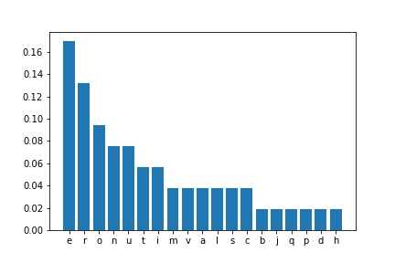